# Google Analytics Capstone: Bellabeats

Sara

2022-08-22

### The following information is from Google Analytics Certificate Program Case Study 2

## Scenario

I am junior data analyst working to a team of marketing analysts at Bellabeat. The stakeholders would like an analysis of data from fitness trackers to find insights about how people are using their fitness trackers. They will use this information to guide a marketing strategy for Bellabeat.

## Company

“Urška Sršen and Sando Mur founded Bellabeat, a high-tech company that manufactures health-focused smart products. Sršen used her background as an artist to develop beautifully designed technology that informs and inspires women around the world. Collecting data on activity, sleep, stress, and reproductive health has allowed Bellabeat to empower women with knowledge about their own health and habits.”

## **Products**

- **Bellabeat app:** The Bellabeat app provides users with health data related to their activity, sleep, stress, menstrual cycle, mindfulness and wellness habits.
- **Leaf:** This wellness tracker can be worn as a bracelet, necklace, or clip; which then connects to the Bellabeat app to track activity, sleep, and stress.
- **Time:** This wellness watch uses smart technology to track user activity, sleep, and stress; and connects to the Bellabeat app to provide you with insights into your daily wellness.
- **Spring:** This is a water bottle that tracks daily water intake. It connects to the Bellabeat app to track your hydration levels.

# **Buisness task**

- **Establish** new growth for the company **by** identifying trends in how fitness trackers data **to** create a marketing strategy.

# Stakeholders

- **Urška Sršen:** Bellabeat’s cofounder and Chief Creative Officer
- **Sando Mur:** Mathematician and Bellabeat’s cofounder

# Data

# **Setting up R and loading Data set**

Notes: Installed packages needed in R for analysis

install.packages(c(“rmarkdown”,“skimr”,“tidyverse”,“janitor”,“lubridate”))

```r
library(rmarkdown)
library(skimr)
library(tidyverse)
library(janitor)
library(lubridate)
```

## **Import Data**

```r
daily_activity <- read_csv("dailyActivity_merged.csv")
hr_seconds <- read_csv("heartrate_seconds_merged.csv")
sleep_day <- read_csv("sleepDay_merged.csv")
```

## **Review Data**

```r
str(daily_activity)
```

```
## spec_tbl_df [940 × 15] (S3: spec_tbl_df/tbl_df/tbl/data.frame)
##  $ Id                      : num [1:940] 1.5e+09 1.5e+09 1.5e+09 1.5e+09 1.5e+09 ...
##  $ ActivityDate            : chr [1:940] "4/12/2016" "4/13/2016" "4/14/2016" "4/15/2016" ...
##  $ TotalSteps              : num [1:940] 13162 10735 10460 9762 12669 ...
##  $ TotalDistance           : num [1:940] 8.5 6.97 6.74 6.28 8.16 ...
##  $ TrackerDistance         : num [1:940] 8.5 6.97 6.74 6.28 8.16 ...
##  $ LoggedActivitiesDistance: num [1:940] 0 0 0 0 0 0 0 0 0 0 ...
##  $ VeryActiveDistance      : num [1:940] 1.88 1.57 2.44 2.14 2.71 ...
##  $ ModeratelyActiveDistance: num [1:940] 0.55 0.69 0.4 1.26 0.41 ...
##  $ LightActiveDistance     : num [1:940] 6.06 4.71 3.91 2.83 5.04 ...
##  $ SedentaryActiveDistance : num [1:940] 0 0 0 0 0 0 0 0 0 0 ...
##  $ VeryActiveMinutes       : num [1:940] 25 21 30 29 36 38 42 50 28 19 ...
##  $ FairlyActiveMinutes     : num [1:940] 13 19 11 34 10 20 16 31 12 8 ...
##  $ LightlyActiveMinutes    : num [1:940] 328 217 181 209 221 164 233 264 205 211 ...
##  $ SedentaryMinutes        : num [1:940] 728 776 1218 726 773 ...
##  $ Calories                : num [1:940] 1985 1797 1776 1745 1863 ...
##  - attr(*, "spec")=
##   .. cols(
##   ..   Id = col_double(),
##   ..   ActivityDate = col_character(),
##   ..   TotalSteps = col_double(),
##   ..   TotalDistance = col_double(),
##   ..   TrackerDistance = col_double(),
##   ..   LoggedActivitiesDistance = col_double(),
##   ..   VeryActiveDistance = col_double(),
##   ..   ModeratelyActiveDistance = col_double(),
##   ..   LightActiveDistance = col_double(),
##   ..   SedentaryActiveDistance = col_double(),
##   ..   VeryActiveMinutes = col_double(),
##   ..   FairlyActiveMinutes = col_double(),
##   ..   LightlyActiveMinutes = col_double(),
##   ..   SedentaryMinutes = col_double(),
##   ..   Calories = col_double()
##   .. )
##  - attr(*, "problems")=<externalptr>
```

```r
str(hr_seconds)
```

```
## spec_tbl_df [2,483,658 × 3] (S3: spec_tbl_df/tbl_df/tbl/data.frame)
##  $ Id   : num [1:2483658] 2.02e+09 2.02e+09 2.02e+09 2.02e+09 2.02e+09 ...
##  $ Time : chr [1:2483658] "4/12/2016 7:21:00 AM" "4/12/2016 7:21:05 AM" "4/12/2016 7:21:10 AM" "4/12/2016 7:21:20 AM" ...
##  $ Value: num [1:2483658] 97 102 105 103 101 95 91 93 94 93 ...
##  - attr(*, "spec")=
##   .. cols(
##   ..   Id = col_double(),
##   ..   Time = col_character(),
##   ..   Value = col_double()
##   .. )
##  - attr(*, "problems")=<externalptr>
```

```r
str(sleep_day)
```

```
## spec_tbl_df [413 × 5] (S3: spec_tbl_df/tbl_df/tbl/data.frame)
##  $ Id                : num [1:413] 1.5e+09 1.5e+09 1.5e+09 1.5e+09 1.5e+09 ...
##  $ SleepDay          : chr [1:413] "4/12/2016 12:00:00 AM" "4/13/2016 12:00:00 AM" "4/15/2016 12:00:00 AM" "4/16/2016 12:00:00 AM" ...
##  $ TotalSleepRecords : num [1:413] 1 2 1 2 1 1 1 1 1 1 ...
##  $ TotalMinutesAsleep: num [1:413] 327 384 412 340 700 304 360 325 361 430 ...
##  $ TotalTimeInBed    : num [1:413] 346 407 442 367 712 320 377 364 384 449 ...
##  - attr(*, "spec")=
##   .. cols(
##   ..   Id = col_double(),
##   ..   SleepDay = col_character(),
##   ..   TotalSleepRecords = col_double(),
##   ..   TotalMinutesAsleep = col_double(),
##   ..   TotalTimeInBed = col_double()
##   .. )
##  - attr(*, "problems")=<externalptr>
```

## **Clean Data And Validate**

Ensure column names are clean.

```r
clean_names(daily_activity)
```

```
## # A tibble: 940 × 15
##            id activity…¹ total…² total…³ track…⁴ logge…⁵ very_…⁶ moder…⁷ light…⁸
##         <dbl> <chr>        <dbl>   <dbl>   <dbl>   <dbl>   <dbl>   <dbl>   <dbl>
##  1 1503960366 4/12/2016    13162    8.5     8.5        0    1.88   0.550    6.06
##  2 1503960366 4/13/2016    10735    6.97    6.97       0    1.57   0.690    4.71
##  3 1503960366 4/14/2016    10460    6.74    6.74       0    2.44   0.400    3.91
##  4 1503960366 4/15/2016     9762    6.28    6.28       0    2.14   1.26     2.83
##  5 1503960366 4/16/2016    12669    8.16    8.16       0    2.71   0.410    5.04
##  6 1503960366 4/17/2016     9705    6.48    6.48       0    3.19   0.780    2.51
##  7 1503960366 4/18/2016    13019    8.59    8.59       0    3.25   0.640    4.71
##  8 1503960366 4/19/2016    15506    9.88    9.88       0    3.53   1.32     5.03
##  9 1503960366 4/20/2016    10544    6.68    6.68       0    1.96   0.480    4.24
## 10 1503960366 4/21/2016     9819    6.34    6.34       0    1.34   0.350    4.65
## # … with 930 more rows, 6 more variables: sedentary_active_distance <dbl>,
## #   very_active_minutes <dbl>, fairly_active_minutes <dbl>,
## #   lightly_active_minutes <dbl>, sedentary_minutes <dbl>, calories <dbl>, and
## #   abbreviated variable names ¹activity_date, ²total_steps, ³total_distance,
## #   ⁴tracker_distance, ⁵logged_activities_distance, ⁶very_active_distance,
## #   ⁷moderately_active_distance, ⁸light_active_distance
```

```r
clean_names(hr_seconds)
```

```
## # A tibble: 2,483,658 × 3
##            id time                 value
##         <dbl> <chr>                <dbl>
##  1 2022484408 4/12/2016 7:21:00 AM    97
##  2 2022484408 4/12/2016 7:21:05 AM   102
##  3 2022484408 4/12/2016 7:21:10 AM   105
##  4 2022484408 4/12/2016 7:21:20 AM   103
##  5 2022484408 4/12/2016 7:21:25 AM   101
##  6 2022484408 4/12/2016 7:22:05 AM    95
##  7 2022484408 4/12/2016 7:22:10 AM    91
##  8 2022484408 4/12/2016 7:22:15 AM    93
##  9 2022484408 4/12/2016 7:22:20 AM    94
## 10 2022484408 4/12/2016 7:22:25 AM    93
## # … with 2,483,648 more rows
```

```r
clean_names(sleep_day)
```

```
## # A tibble: 413 × 5
##            id sleep_day             total_sleep_records total_minutes_…¹ total…²
##         <dbl> <chr>                               <dbl>            <dbl>   <dbl>
##  1 1503960366 4/12/2016 12:00:00 AM                   1              327     346
##  2 1503960366 4/13/2016 12:00:00 AM                   2              384     407
##  3 1503960366 4/15/2016 12:00:00 AM                   1              412     442
##  4 1503960366 4/16/2016 12:00:00 AM                   2              340     367
##  5 1503960366 4/17/2016 12:00:00 AM                   1              700     712
##  6 1503960366 4/19/2016 12:00:00 AM                   1              304     320
##  7 1503960366 4/20/2016 12:00:00 AM                   1              360     377
##  8 1503960366 4/21/2016 12:00:00 AM                   1              325     364
##  9 1503960366 4/23/2016 12:00:00 AM                   1              361     384
## 10 1503960366 4/24/2016 12:00:00 AM                   1              430     449
## # … with 403 more rows, and abbreviated variable names ¹total_minutes_asleep,
## #   ²total_time_in_bed
```

### **Find Missing Values**

```r
is.null(daily_activity)
```

```
## [1] FALSE
```

```r
is.null(hr_seconds)
```

```
## [1] FALSE
```

```r
is.null(sleep_day)
```

```
## [1] FALSE
```

### **Find Duplicate Data**

```r
sum(duplicated(daily_activity))
```

```
## [1] 0
```

```r
sum(duplicated(sleep_day))
```

```
## [1] 3
```

```r
sum(duplicated(hr_seconds))
```

```
## [1] 0
```

3 Duplicates found in sleep_day data

### **Remove Duplicate Data**

```r
sleep_day<- unique(sleep_day)
```

### **Recheck for Duplicates**

```r
sum(duplicated(sleep_day))
```

```
## [1] 0
```

### **Check Length(number of Users) for data**

```r
length(unique(daily_activity$Id))
```

```
## [1] 33
```

```r
length(unique(hr_seconds$Id))
```

```
## [1] 14
```

```r
length(unique(sleep_day$Id))
```

```
## [1] 24
```

## **Fix any inconsistencies, manipulate data to find relevant information and combine data**

### **Change dates to standard format**

```r
daily_activity$ActivityDate = as.POSIXct(daily_activity$ActivityDate,tz=Sys.timezone(),format="%m/%d/%Y")

hr_seconds$Time = as.POSIXct(hr_seconds$Time,tz=Sys.timezone(),format="%m/%d/%Y")

sleep_day$SleepDay = as.POSIXct(sleep_day$SleepDay ,tx=Sys.timezone(), format = "%m/%d/%Y ")

hr_seconds$Time = format(hr_seconds$Time,format='%Y/%m/%d')
```

```r
sleep_day$minNotAsleep = (sleep_day$TotalTimeInBed - sleep_day$TotalMinutesAsleep)

sleep_day$hoursSleep = (sleep_day$TotalMinutesAsleep / 60)
sleep_day$hoursSleep = round(sleep_day$hoursSleep,digits = 1)
```

```r
sleep_day <- rename(sleep_day,ActivityDate=SleepDay)

daily_activity_1 <- merge(daily_activity,sleep_day, by=c("Id","ActivityDate"))
```

### **Find the daily maximum,minimum and average heart rate and round average to the nearest whole number**

```r
hr_seconds_sum <- hr_seconds %>%
  group_by(Id,Time) %>%
  summarize(MaxHeartRate = max(Value,na.rm=T),
            MinHeartRate = min(Value,na.rm=T),
            AvgHeartRate = mean(Value,na.rm=T)) %>%
           arrange(Id,Time)
```

[output not shown]

```r
 hr_seconds_sum$AvgHeartRate = round(hr_seconds_sum$AvgHeartRate,digits = 0)
```

### **Rename the Time column to ActiveDate to be consistent with other data**

```r
hr_seconds_sum <- rename(hr_seconds_sum,ActivityDate=Time)

daily_activity_all <- merge(daily_activity_1,hr_seconds_sum, by=c("Id","ActivityDate"))
```

### **Calculate toalta active minutes and combine data**

```r
daily_activity_all <- daily_activity_all %>%
   mutate(TotalActiveMinutes = rowSums(across(c(VeryActiveMinutes,FairlyActiveMinutes,LightlyActiveMinutes))))

View(daily_activity_all)
```

Now all my data has been cleaned and double checked.

# **Analysis**

### **Review Summaries**

```r
daily_activity_all %>%
select(TotalSteps, TotalDistance,TotalActiveMinutes,hoursSleep,minNotAsleep,MinHeartRate,MaxHeartRate,AvgHeartRate,SedentaryMinutes) %>%
  summary()
```

```
##    TotalSteps    TotalDistance    TotalActiveMinutes   hoursSleep
##  Min.   :   42   Min.   : 0.030   Min.   :  4.0      Min.   : 1.000
##  1st Qu.: 5245   1st Qu.: 3.680   1st Qu.:217.0      1st Qu.: 6.500
##  Median : 9148   Median : 6.380   Median :283.0      Median : 7.300
##  Mean   : 8522   Mean   : 6.021   Mean   :273.2      Mean   : 7.106
##  3rd Qu.:11135   3rd Qu.: 7.920   3rd Qu.:333.0      3rd Qu.: 8.200
##  Max.   :22770   Max.   :17.540   Max.   :540.0      Max.   :12.900
##   minNotAsleep    MinHeartRate    MaxHeartRate    AvgHeartRate
##  Min.   : 0.00   Min.   :36.00   Min.   : 80.0   Min.   : 59.00
##  1st Qu.:16.00   1st Qu.:45.00   1st Qu.:123.0   1st Qu.: 67.00
##  Median :24.00   Median :51.00   Median :133.0   Median : 73.00
##  Mean   :28.55   Mean   :49.97   Mean   :135.5   Mean   : 73.67
##  3rd Qu.:39.00   3rd Qu.:54.00   3rd Qu.:149.0   3rd Qu.: 79.00
##  Max.   :94.00   Max.   :70.00   Max.   :199.0   Max.   :105.00
##  SedentaryMinutes
##  Min.   :   2
##  1st Qu.: 621
##  Median : 707
##  Mean   : 702
##  3rd Qu.: 781
##  Max.   :1222
```

From this summary, consumers are meeting an average of 8522 steps a day. Havard Health suggests that there is benefit for meeting a 7500 step goal a day. (link)https://www.health.harvard.edu/staying-healthy/how-many-steps-should-i-take-each-day. The cdc recommends getting more the 7 hours or more of sleep a night the average showen is 7 (link)https://www.cdc.gov/sleep/about_sleep/how_much_sleep.html There is relevant information about the highest daily heart rate but the the maxium is bordering out of normal range and the highest average heart rate is also above normal range.

## ** PLot Data

Review the correlation between daily steps taken and calories burned.

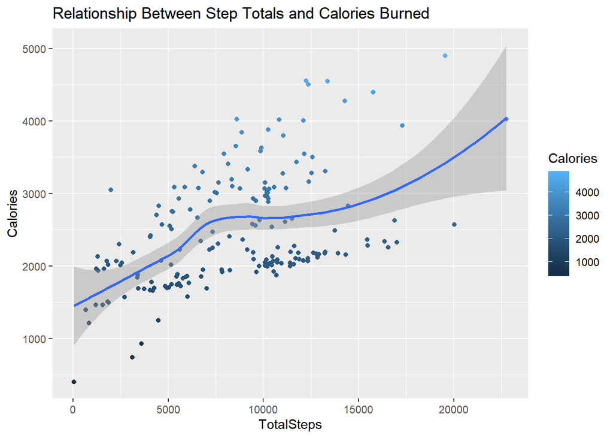

```r
ggplot(daily_activity_all,aes(x=TotalSteps,y=Calories,colour=Calories))+
  geom_point()+
  geom_smooth()+
  labs(title = "Relationship Between Step Totals and Calories Burned")
```

Correlation Identified, review if correlation is the same between with total activity minutes and calories burned.

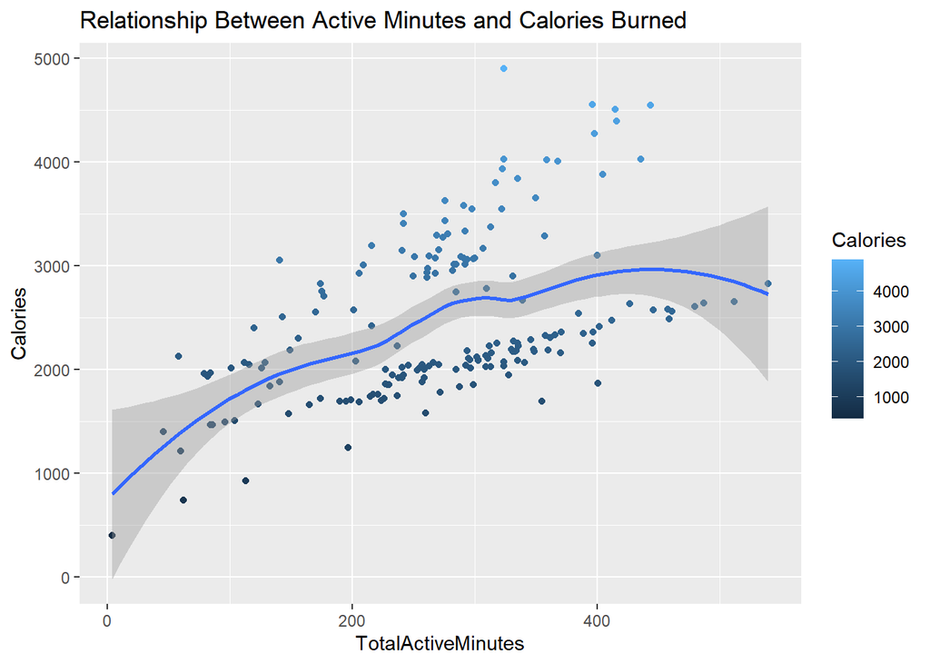

```r
ggplot(daily_activity_all,aes(x=TotalActiveMinutes,y=Calories,color=Calories))+
  geom_point()+
  geom_smooth()+
  labs(title = "Relationship Between Active Minutes and Calories Burned")
```

Same correlation identified. Analysis any correlation with Calories burned and hours of sleep.

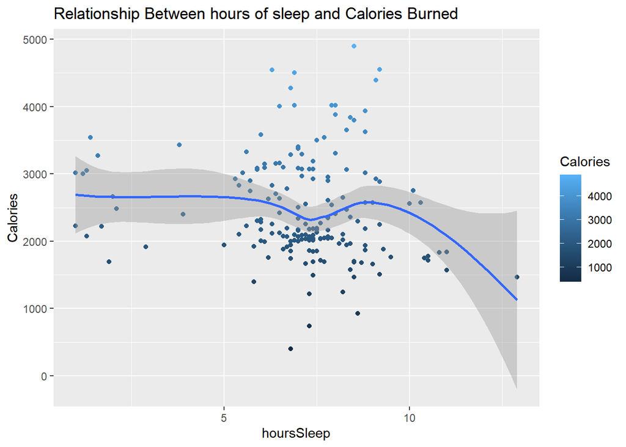

```r
ggplot(daily_activity_all,aes(x=hoursSleep,y=Calories,colour=Calories))+
  geom_point()+
  geom_smooth()+
  labs(title = "Relationship Between hours of sleep and Calories Burned")
```

Identify if there is any correlation between average heart rate, lowest heart rate and highest heart rate; with calories burned

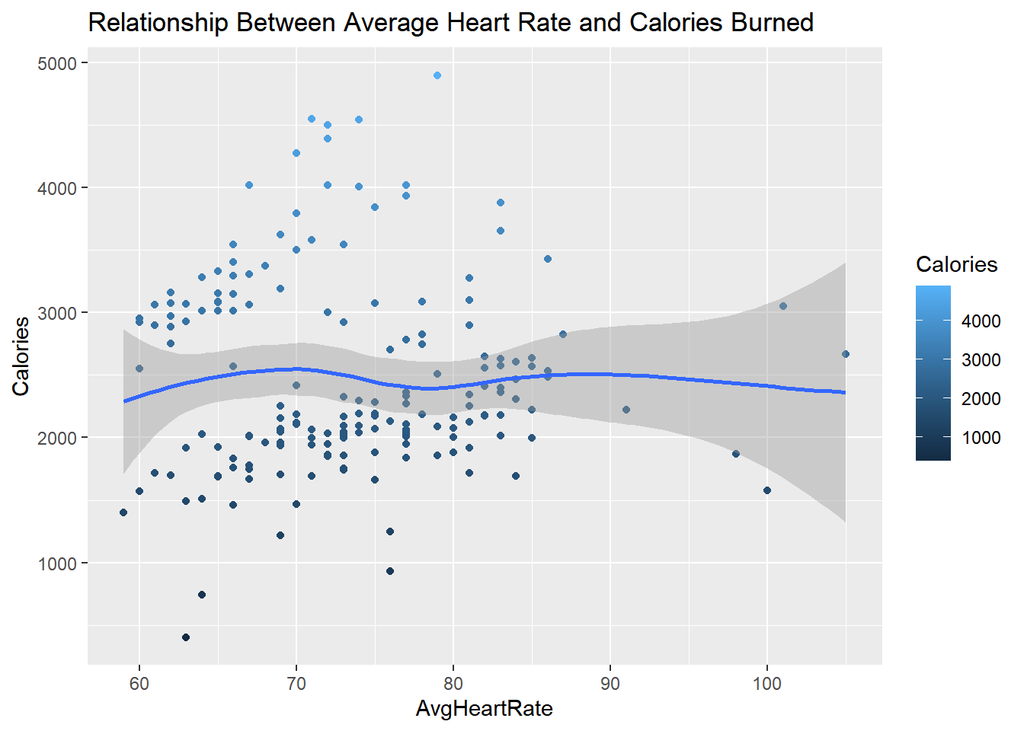

```r
ggplot(daily_activity_all,aes(x=AvgHeartRate,y=Calories,colour=Calories))+
  geom_point()+
  geom_smooth()+
  labs(title = "Relationship Between Average Heart Rate and Calories Burned")
```

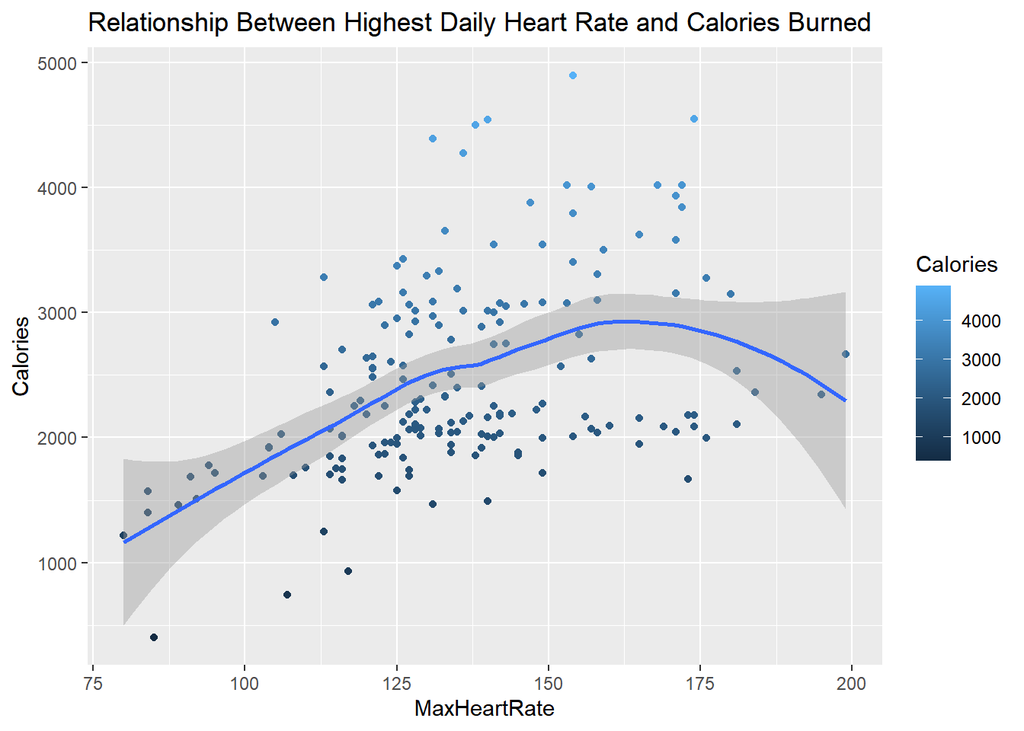

```r
ggplot(daily_activity_all,aes(x=MaxHeartRate,y=Calories,colour=Calories))+
  geom_point()+
  geom_smooth()+
  labs(title = "Relationship Between Highest Daily Heart Rate and Calories Burned")
```

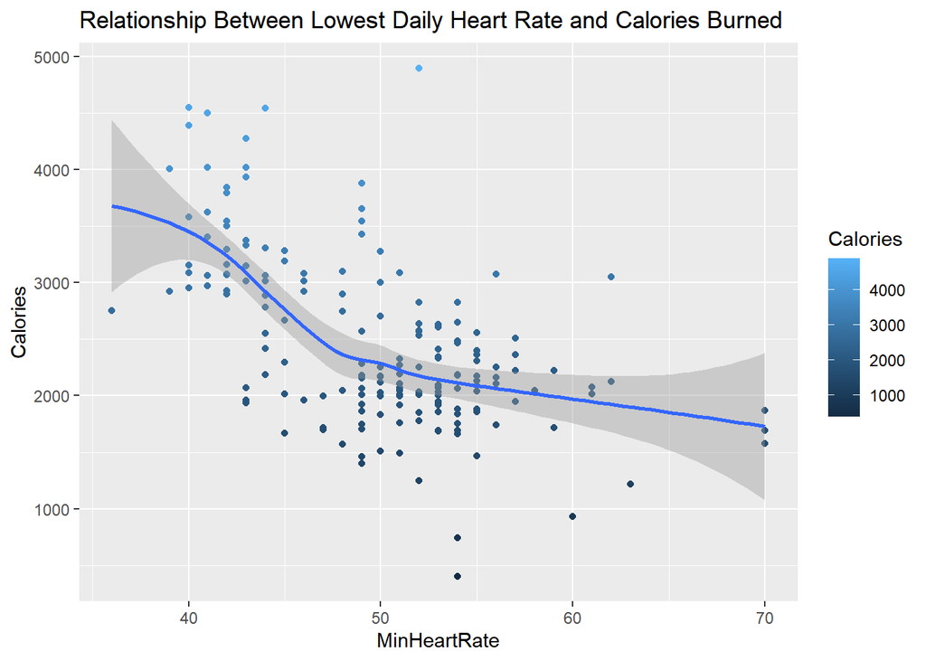

```r
ggplot(daily_activity_all,aes(x=MinHeartRate,y=Calories,colour=Calories))+
  geom_point()+
  geom_smooth()+
  labs(title = "Relationship Between Lowest Daily Heart Rate and Calories Burned")
```

From these graphs there is clearly a positive relationship between the amount of steps/active minutes and how many calories are burned. It appears as though sleep does not correlate with the amount of calories burned except in the case where hours asleep are greater than 10 then there seems to be less calories burned. It also appears as though there is a positive correlation for the amount of calories burned with highest daily heart rate until about 162 beats per minutes, after that there is a negative correlation. There seems to be a correlation between lowest daily heart rate and calories burned where the lower the lowest the daily heart rate is the more calories burnt.

Identify if there is a correlation between lowest daily heart rate and activity minutes

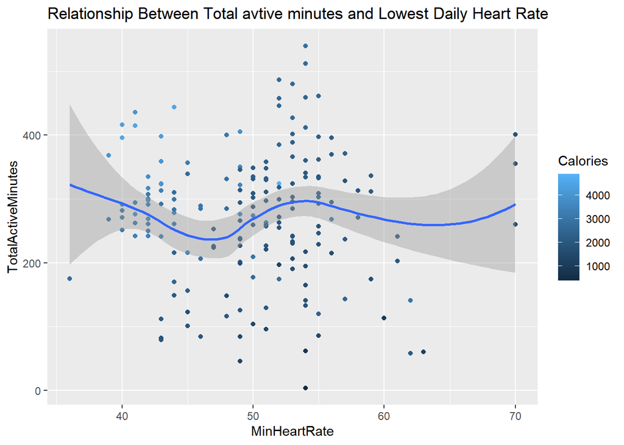

```r
ggplot(daily_activity_all,aes(x=MinHeartRate,y=TotalActiveMinutes,colour=Calories))+
  geom_point()+
  geom_smooth()+
  labs(title = "Relationship Between Total avtive minutes and Lowest Daily Heart Rate")
```

Correlation not seen.

View relationship between Total steps and lowest daily heart rate

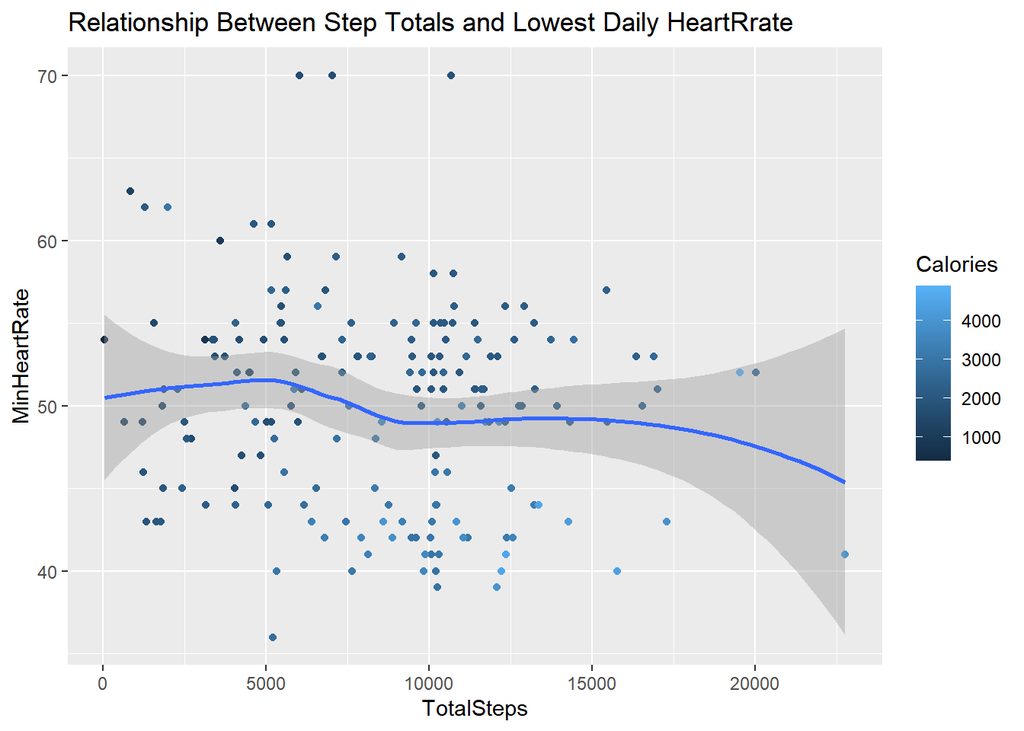

```r
ggplot(daily_activity_all,aes(x=TotalSteps,y=MinHeartRate,colour=Calories))+
  geom_point()+
  geom_smooth()+
  labs(title = "Relationship Between Step Totals and Lowest Daily HeartRrate")
```

Identify if there is a correlation between sleep and lowest average heart rate

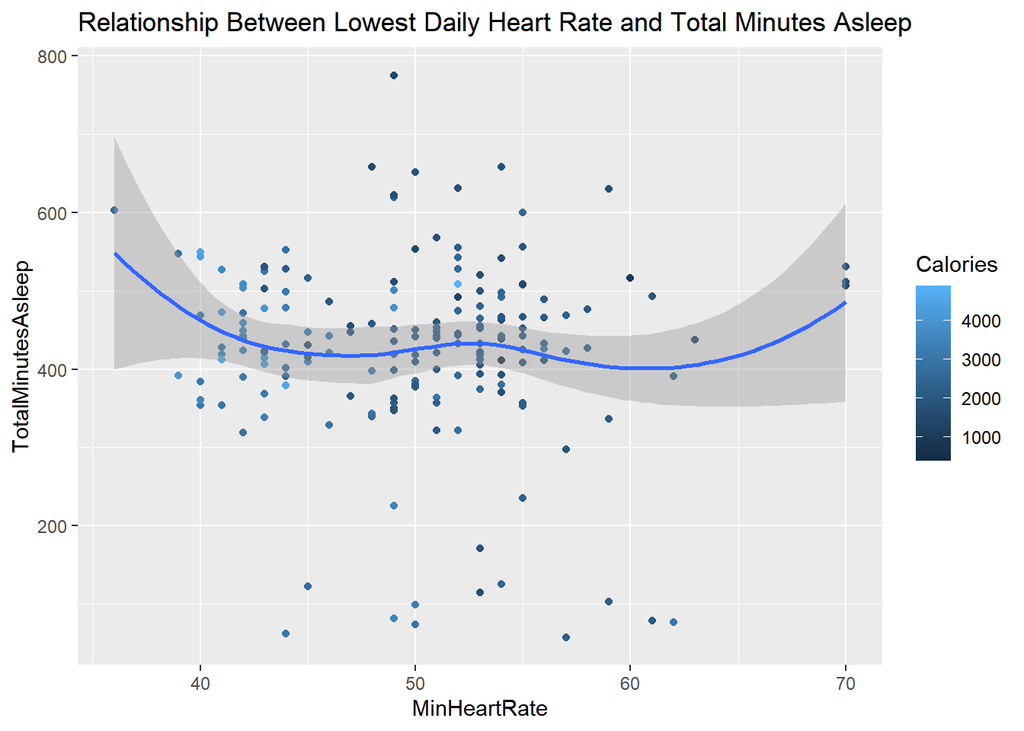

```r
ggplot(daily_activity_all,aes(x=MinHeartRate,y=TotalMinutesAsleep,colour=Calories))+
  geom_point()+
  geom_smooth()+
  labs(title = "Relationship Between Lowest Daily Heart Rate and Total Minutes Asleep")
```

No relationship noted.

Identify correlations between minutes in bed

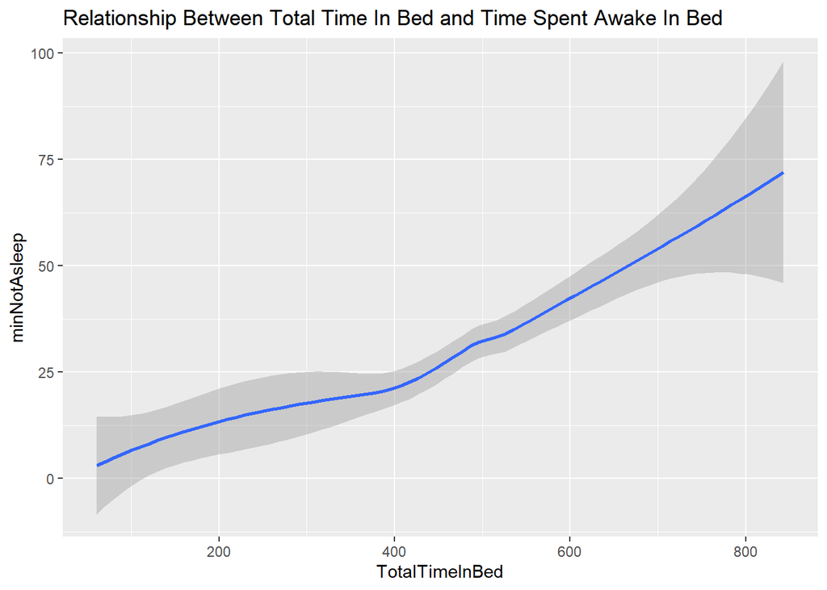

```r
ggplot(data=daily_activity_all) +
  geom_smooth(mapping=aes(x=TotalTimeInBed,y=minNotAsleep)) +
  labs(title="Relationship Between Total Time In Bed and Time Spent Awake In Bed")
```

Correlation identified between minutes awake in bed and total time in bed.

Graph to determine the amount of hours of sleep individuals averaged.

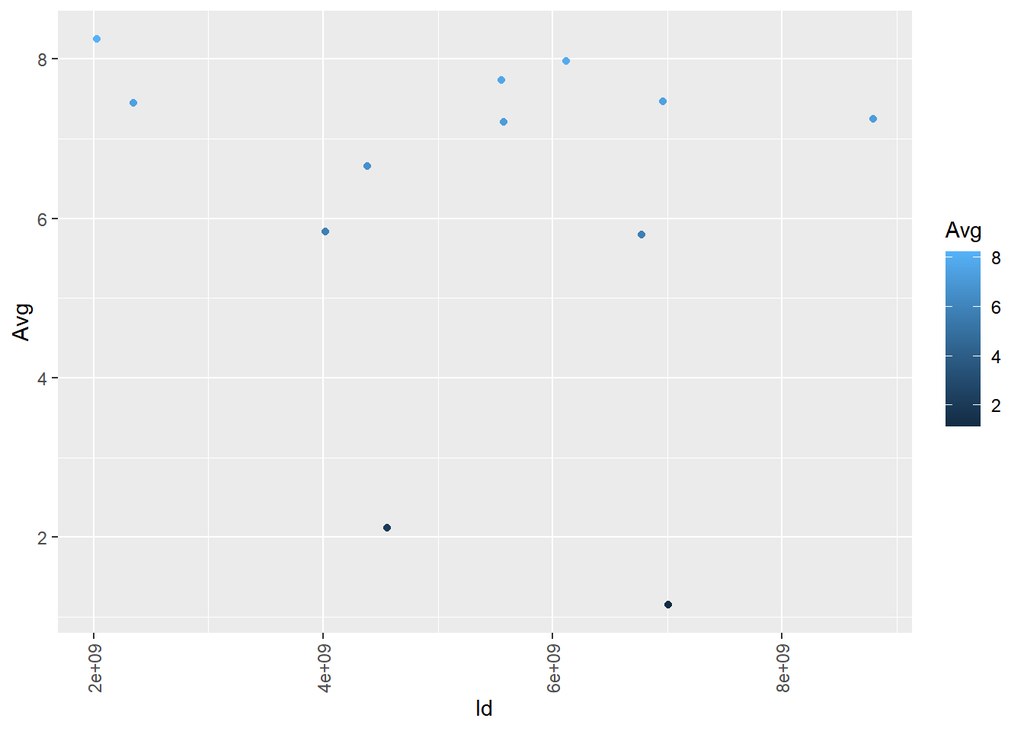

```r
daily_activity_all %>%
   group_by(Id) %>%
  summarize(Avg = mean(hoursSleep,na.rm=T)) %>%
  ggplot() +
  geom_point(aes(x=Id, y=Avg,color = Avg)) +
  theme(axis.text.x=element_text(angle = 90, vjust = 0.5))
```

Identified that many consumers are not getting the recommended amount of sleep on average.